# Reading the Titanic dataset

## File details

This program was written by Steve Simon on 2025-01-06 and is placed in the public domain. You can use this program any way you please.

This program reads data on mortality of passengers on the Titanic. Refer to the [data dictionary](https://github.com/pmean/data/blob/main/files/titanic.yaml) for a more detailed description.

```r
R.version.string
```

```
[1] "R version 4.3.0 (2023-04-21 ucrt)"
```

```r
Sys.Date()
```

```
[1] "2025-01-16"
```

```r
library(epitools)
library(glue)
library(tidyverse)
```

#### Documentation of the intermediate datasets

- ti: Data as originally read in from the text file
- ti_1: Convert survived to a factor
- ti_2: Created new variable, third_class
- ti_3: Created new variable, child
- pclass_counts: counts and percentages for each passenger class
- sex_survived_crosstab: counts for survived by sex

## Reading in the Titanic data set

```r
fn <- "../data/titanic.csv"
ti <- read_csv(fn,
  col_types="ccncn")
glimpse(ti)
```

```
Rows: 1,313
Columns: 5
$ name     <chr> "Allen, Miss Elisabeth Walton", "Allison, Miss Helen Loraine"…
$ pclass   <chr> "1st", "1st", "1st", "1st", "1st", "1st", "1st", "1st", "1st"…
$ age      <dbl> 29.00, 2.00, 30.00, 25.00, 0.92, 47.00, 63.00, 39.00, 58.00, …
$ sex      <chr> "female", "female", "male", "female", "male", "male", "female…
$ survived <dbl> 1, 0, 0, 0, 1, 1, 1, 0, 1, 0, 0, 1, 1, 1, 0, 1, 0, 0, 1, 1, 1…
```

## Peek at the bottom of the data

```r
ti |>
  slice_tail(n=10)
```

```
# A tibble: 10 × 5
   name                   pclass   age sex    survived
   <chr>                  <chr>  <dbl> <chr>     <dbl>
 1 Yasbeck, Mr Antoni     3rd       27 male          0
 2 Yasbeck, Mrs Antoni    3rd       15 female        1
 3 Youssef, Mr Gerios     3rd       NA male          0
 4 Zabour, Miss Hileni    3rd       NA female        0
 5 Zabour, Miss Tamini    3rd       NA female        0
 6 Zakarian, Mr Artun     3rd       27 male          0
 7 Zakarian, Mr Maprieder 3rd       26 male          0
 8 Zenni, Mr Philip       3rd       22 male          0
 9 Lievens, Mr Rene       3rd       24 male          0
10 Zimmerman, Leo         3rd       29 male          0
```

#### Comments on the code

The [slice_tail](https://dplyr.tidyverse.org/reference/slice.html) function (part of the dplyr/tidyverse libraries) displays one or more rows of data at the bottom of a data set. This is similar to the [tail](https://stat.ethz.ch/R-manual/R-devel/library/utils/html/head.html) function in base R.

For large files, it is often worthwhile to look at the bottom of dataset after you read it in. Often the first few rows of data look fine. but problems crop up in the middle of the file which distort the data from that point onward. Other times, you might find stray comments or extra blank lines at the end of a text file. You won’t notice these problems if you don’t look at the bottom of the file.

## Descriptive statistics on age

```r
ti |>
  summarize(
    age_mean=round(mean(age, na.rm=TRUE), 1),
    age_sd=round(sd(age, na.rm=TRUE), 1),
    age_min=min(age, na.rm=TRUE),
    age_max=max(age, na.rm=TRUE),
    age_missing=sum(is.na(age)))
```

```
# A tibble: 1 × 5
  age_mean age_sd age_min age_max age_missing
     <dbl>  <dbl>   <dbl>   <dbl>       <int>
1     30.4   14.3    0.17      71         557
```

## Counts and percentages

```r
ti |>
  count(pclass) |>
  mutate(total=sum(n)) |>
  mutate(pct=100*n/total) -> pclass_counts
pclass_counts
```

```
# A tibble: 3 × 4
  pclass     n total   pct
  <chr>  <int> <int> <dbl>
1 1st      322  1313  24.5
2 2nd      280  1313  21.3
3 3rd      711  1313  54.2
```

#### Comments on the code

The [count](https://dplyr.tidyverse.org/reference/count.html) function (part of the dplyr/tidyverse libraries) counts the number of observations in each level of a categorical variable. You can also use the [table](https://stat.ethz.ch/R-manual/R-devel/library/base/html/table.html) function in base R, which produces results in a slightly different format.

The [sum](https://stat.ethz.ch/R-manual/R-devel/library/base/html/sum.html) function adds up all the values. When placed inside the mutate function, it creates a new column with the same sum beside each row. This allows us to compute a percentage later.

## Nice looking percentages

```r
pclass_counts |>
  mutate(pct=glue("{n}/{total} ({round(pct)}%)")) |>
  select(-n, -total)
```

```
# A tibble: 3 × 2
  pclass pct
  <chr>  <glue>
1 1st    322/1313 (25%)
2 2nd    280/1313 (21%)
3 3rd    711/1313 (54%)
```

#### Comments on the code

The [glue](https://glue.tidyverse.org/) function (part of the glue library) allows you to insert numbers into nicely formatted strings. You can also use the [paste and paste0](https://stat.ethz.ch/R-manual/R-devel/library/base/html/paste.html) functions to do the same thing. If you are familiar with how C and C++ produces nicely formatted output, you might consider using the [sprintf](https://stat.ethz.ch/R-manual/R-devel/library/base/html/sprintf.html) function.

#### Interpretation of the output

More than half of the passengers were in third class. Among the remaining passengers, there were slightly more first class than second class passengers.

## Bar chart with counts

```r
pclass_counts |>
  ggplot() +
    aes(x=pclass, y=n) +
    geom_col(color="black", fill="white")
    ggtitle("Graph drawn by Steve Simon on 2025-01-16") +
    xlab("Passenger class") +
    ylab("Count") +
    coord_flip() +
```

[output not shown]

[output not shown]

## Bar chart with percents

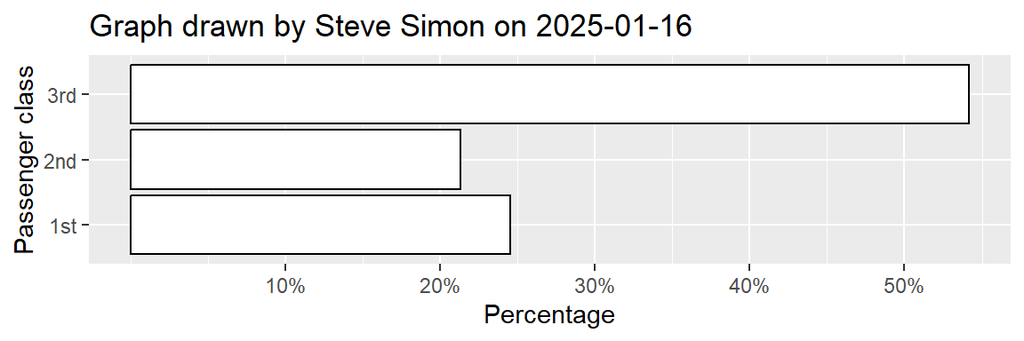

```r
ticks <- c(10, 20, 30, 40, 50)
pclass_counts |>
  mutate(pct=100*n/total) |>
  ggplot() +
    aes(x=pclass, y=pct) +
    geom_col(color="black", fill="white") +
    ggtitle("Graph drawn by Steve Simon on 2025-01-16") +
    xlab("Passenger class") +
    ylab("Percentage") +
    scale_y_continuous(breaks=ticks, labels=glue("{ticks}%")) +
    coord_flip()
```

## Creating factors, 1

```r
ti |>
  mutate(
    survived=
      factor(
        survived,
        levels=c(0, 1),
        labels=c("dead", "alive"))) -> ti_1
```

## Creating factors, 2

```r
ti_1 |>
  count(survived) |>
  mutate(total=sum(n)) |>
  mutate(pct=round(100*n/total)) |>
  mutate(pct=glue("{n}/{total} ({pct}%)")) |>
  select(-n, -total)
```

```
# A tibble: 2 × 2
  survived pct
  <fct>    <glue>
1 dead     863/1313 (66%)
2 alive    450/1313 (34%)
```

#### Interpretation of the output

Things did not go well for the passengers of the Titanic. Only about a third of the passengers survived.

## Re-ordering categories

```r
ti_1 |>
  mutate(pclass=factor(pclass, levels=c("3rd", "2nd", "1st"))) |>
  count(pclass) |>
  mutate(total=sum(n)) |>
  mutate(pct=round(100*n/total)) |>
  mutate(pct=glue("{n}/{total} ({pct}%)")) |>
  select(-n, -total)
```

```
# A tibble: 3 × 2
  pclass pct
  <fct>  <glue>
1 3rd    711/1313 (54%)
2 2nd    280/1313 (21%)
3 1st    322/1313 (25%)
```

## Recoding categorical data, 1

```r
ti_1 |>
  mutate(
    third_class=
      case_when(
        is.na(pclass) ~ "unknown",
        pclass=="1st" ~ "no",
        pclass=="2nd" ~ "no",
        pclass=="3rd" ~ "yes")) -> ti_2
```

## Recoding categorical data, 2

```r
ti_2 |>
  count(third_class) |>
  mutate(total=sum(n)) |>
  mutate(pct=round(100*n/total)) |>
  mutate(pct=glue("{n}/{total} ({pct}%)")) |>
  select(-n, -total)
```

```
# A tibble: 2 × 2
  third_class pct
  <chr>       <glue>
1 no          602/1313 (46%)
2 yes         711/1313 (54%)
```

#### Comments on the code

The [case_when](https://dplyr.tidyverse.org/reference/case_when.html) function (part of the dplyr/tidyverse libraries) creates a new variable or modifies an old variable based on a sequence of logical conditions.

#### Interpretation of the output

As noted earlier, a bit more than half of the passengers were in third class.

## Converting continuous data to categorical data, 1

```r
ti_2 |>
  mutate(
    child=
      case_when(
        is.na(age) ~ "Unknown",
        age <= 0 ~ "Invalid",
        age < 18 ~ "Yes",
        TRUE ~ "No")) -> ti_3
```

## Converting continuous data to categorical data, 2

```r
ti_3 |>
  count(child) |>
  mutate(total=sum(n)) |>
  mutate(pct=round(100*n/total)) |>
  mutate(pct=glue("{n}/{total} ({pct}%)")) |>
  select(-n, -total)
```

```
# A tibble: 3 × 2
  child   pct
  <chr>   <glue>
1 No      660/1313 (50%)
2 Unknown 557/1313 (42%)
3 Yes     96/1313 (7%)
```

## Two way crosstabulation

```r
ti_3 |>
    count(sex, survived) -> sex_survived_crosstab
sex_survived_crosstab
```

```
# A tibble: 4 × 3
  sex    survived     n
  <chr>  <fct>    <int>
1 female dead       154
2 female alive      308
3 male   dead       709
4 male   alive      142
```

## Overall percents

```r
sex_survived_crosstab |>
  mutate(total=sum(n)) |>
  mutate(pct=round(100*n/total))
```

```
# A tibble: 4 × 5
  sex    survived     n total   pct
  <chr>  <fct>    <int> <int> <dbl>
1 female dead       154  1313    12
2 female alive      308  1313    23
3 male   dead       709  1313    54
4 male   alive      142  1313    11
```

## Percents by sex

```r
sex_survived_crosstab |>
  group_by(sex) |>
  mutate(total=sum(n)) |>
  mutate(pct=round(100*n/total)) |>
  filter(survived=="alive") |>
  mutate(pct_survived=glue("{pct}% ({n}/{total})")) |>
  ungroup() |>
  select(survived, pct_survived)
```

```
# A tibble: 2 × 2
  survived pct_survived
  <fct>    <glue>
1 alive    67% (308/462)
2 alive    17% (142/851)
```

## Percents by survived

```r
sex_survived_crosstab |>
  group_by(survived) |>
  mutate(total=sum(n)) |>
  mutate(pct=round(100*n/total)) |>
  filter(sex=="female")  |>
  mutate(pct_female=glue("{pct}% ({n}/{total})")) |>
  ungroup() |>
  select(sex, pct_female)
```

```
# A tibble: 2 × 2
  sex    pct_female
  <chr>  <glue>
1 female 18% (154/863)
2 female 68% (308/450)
```

## Arranged in a table

```r
sex_survived_crosstab |>
    pivot_wider(
        names_from="survived",
        values_from="n") -> sex_survived_crosstabtable
sex_survived_crosstabtable
```

```
# A tibble: 2 × 3
  sex     dead alive
  <chr>  <int> <int>
1 female   154   308
2 male     709   142
```

## clustered bar chart, 1

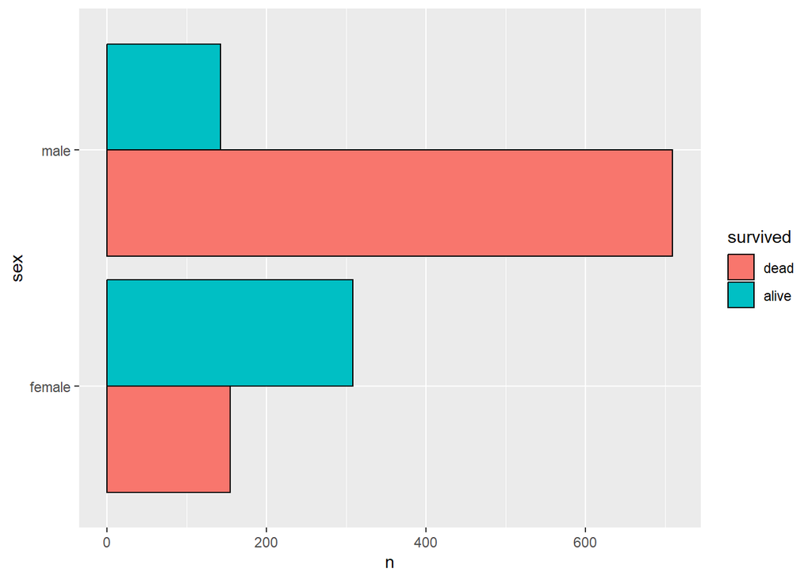

```r
sex_survived_crosstab |>
    ggplot() +
      aes(x=sex, y=n, fill=survived) +
    coord_flip() +
      geom_col(
        color="black",
        position="dodge")
```

## clustered bar chart, 2

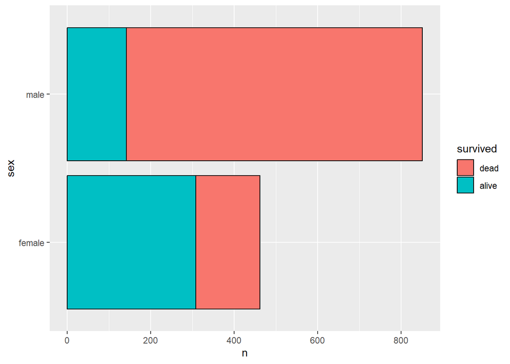

```r
sex_survived_crosstab |>
    ggplot() +
      aes(x=sex, y=n, fill=survived) +
    coord_flip() +
      geom_col(
        color="black",
        position="stack")
```

## Odds ratio

```r
oddsratio(x=ti_3$sex, y=ti_3$survived)
```

```
$data
         Outcome
Predictor dead alive Total
   female  154   308   462
   male    709   142   851
   Total   863   450  1313

$measure
         odds ratio with 95% C.I.
Predictor  estimate      lower     upper
   female 1.0000000         NA        NA
   male   0.1004472 0.07686819 0.1305053

$p.value
         two-sided
Predictor midp.exact fisher.exact   chi.square
   female         NA           NA           NA
   male            0 4.826448e-74 3.425855e-74

$correction
[1] FALSE

attr(,"method")
[1] "median-unbiased estimate & mid-p exact CI"
```

## Relative risk

```r
riskratio(x=ti_3$sex, y=ti_3$survived)
```

```
$data
         Outcome
Predictor dead alive Total
   female  154   308   462
   male    709   142   851
   Total   863   450  1313

$measure
         risk ratio with 95% C.I.
Predictor  estimate     lower     upper
   female 1.0000000        NA        NA
   male   0.2502938 0.2125647 0.2947195

$p.value
         two-sided
Predictor midp.exact fisher.exact   chi.square
   female         NA           NA           NA
   male            0 4.826448e-74 3.425855e-74

$correction
[1] FALSE

attr(,"method")
[1] "Unconditional MLE & normal approximation (Wald) CI"
```